# 10_Practical; Wk. 11 - Iris

### Part (b): Hierarchical Clustering

#### 1. Cluster the observations using complete linkage.

The observations may be clustered using complete linkeage by using the `hclust` package (be mindful to scale the data if necessary, in this case we will):

```r
dst <- iris.sc.input %>% dist()
hc.iris.complete <- hclust(dst, method = 'complete')
```

#### 2. Cluster the observations using average and single linkage.

```r
hc.iris.average  <- hclust(dst, method = 'average')
hc.iris.single   <- hclust(dst, method = 'single')
```

##### Plot the Predictions

Now that the models have been made, by specifying the number of groups required, the function `cutree` will determine at what height to cut off the dendogram:

[figure not shown]

```r
hcPreds <- cutree(hc.iris.complete, k = 3)

# Make the Data
groupPred <- factor(hcPreds, levels = c(1,2,3), ordered = FALSE)
iris$KMpred <- groupPred


# Plot the Data
ggplot(iris, aes(y = Sepal.Length, x = Sepal.Width, col = KMpred)) +
  geom_point() +
  labs(col = "Predicted\nGroup", caption = "Ellipses represent 90% Normal confidence levels,\n
       predictions made using K-means algorithm with 2 classes") +
  stat_ellipse(level = 0.9) +
  theme_cowplot()
```

#### 3. Plot the dendrogram for the above clustering methods.

the `dendextend::` package can make it possible to colour dendograms:

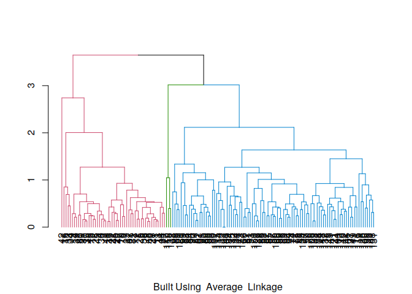

[figure not shown]

[figure not shown]

```r
mods <- list(hc.iris.average, hc.iris.complete, hc.iris.single)




type.vec <- c("Average", "Complete", "Single")

for (hc in mods) {

 hc <-  hc %>%    # Comment out for base without dendextend
   as.dendrogram() %>% set("branches_k_color", k = 3) %>%
   set("leaves_cex", 0.2)


  i <- 1
 plot(hc, sub = paste("Built Using ", type.vec[i], " Linkage"), xlab = "", cex = 0.3)
 i <- i+1
}
```

```r
cols = c("red", "blue", "yellow", "green")[cutree(hc.iris.average, k = 3)]
```

## Question 02:

Generate the data set using the following codes:

```r
set.seed(2)
x = matrix(rnorm(50*2), ncol = 2)
x[1:25, 1]= x[1:25, 1] + 3
x[1:25, 2] = x[1:25, 2] - 4
```

Refer to the file containing the TB Working `./11_PracitcalTut’

### Part (a): k-means clustering

#### 1. Cluster the data set into 2 groups using k-means clustering.

#### 2. Draw a plot to visualize the clusters

#### 3. Cluster the data set into 3 groups using k-means clustering.

#### 4. Draw a plot to visualize the clusters

#### 5. Compare the total within-cluster sum of squares when nstart = 1 to 20.

### Part (b): Hierarchical Clustering

#### 1. Cluster the observations using complete linkage.

#### 2. Cluster the observations using average and single linkage.

#### 3. Plot the dendrogram for the above clustering methods.